# RDA project

JBNU statistics

2021 12 14

## 목적 : 단동 비닐하우스 환기율 및 온습도에 대한 예측모형 구축 및 평가 (반응변수 : 내외부상대습도차)

## 사용모형 : Multiple Linear Regression Model v.s Artificial Neural Network Model (ANN)

## 0. 분석방향

- 내외부상대습도차를 반응변수로, 외부기온, 외부상대습도, 외부풍속, 외부일사량, 환기창면적을 독립변수로 하는 선형회귀모형 적합.
- 내부상대습도를 반응변수로 했던 4번 항목과 외부상대습도의 기울기 추정값의 차이를 제외하고는 같은 결과를 준다.
- 작물유무에 따라 실험이 수행되었으므로 두 경우에 각각 다른 모형을 적합해보고, 두 데이터세트를 합쳐서 작물유무를 추가 독립변수로 가지는 모형을 또한 적합하여 본다.
- 환기율은 외부기온, 외부풍속, 환기창면적 등에 의해 계산되는 값이다. 이 변수들이 이미 독립변수로 고려되었으므로 환기율은 독립변수에 포함시키지 않는다.
- 고려하는 독립변수들은 모두 어느 정도의 중요도를 가진다고 판단된다. 따라서, 영향력이 큰 변수들을 골라내어 단순화된 모형을 찾는 것이 본 분석의 일차적인 목적은 아닐 수 있다.
- 독립변수들간의 교호작용(혹은 상호작용: interaction effect)이 존재할 수 있다. 하지만 교호작용의 포함은 모형의 해석을 난해하게 만들 수 있다.
- 위 요소들을 종합하여, (1) 가능한 모든 효과를 포함한 모형 (2) 예측성능 혹은 변수선택측도 등의 차원에서 가장 우수한 모형 (3) 모든 독립변수들의 주효과를 포함하되 교호작용은 최소한으로 포함한 모형, 크게 3개의 차원에서 모형을 살펴보고 그 예측성능 및 설명력 등을 비교하여 보겠다.

## 1. Loading data (내외부상대습도차 반응변수)

- 작물있음 데이터에서 외부CO2의 값이 결측치인 경우는 제외하였음.

```r
# setwd("D:/OneDrive - 전북대학교/전북대학교/농림과학원용역/2021")
plantyes <- read.csv("C:/Users/stat/Desktop/작물있음.csv",sep=",",header=T)
plantyes <- plantyes[is.na(plantyes$외부CO2)==FALSE,]
head(plantyes,10)
```

```
##    외부기온 내부기온 내외부기온차 외부상대습도 내부상대습도 내외부상대습도차
## 1      22.9     31.1          8.3         78.7         55.0             23.7
## 2      22.8     29.7          6.9         77.1         58.7             18.4
## 3      23.3     29.7          6.4         75.5         58.4             17.1
## 4      23.6     29.8          6.2         72.9         57.8             15.1
## 5      24.0     30.0          6.0         71.2         56.4             14.8
## 6      25.1     33.3          8.1         66.6         49.6             17.0
## 7      25.9     35.6          9.7         66.0         43.6             22.4
## 8      25.0     34.0          8.9         68.0         44.9             23.1
## 9      25.9     33.7          7.8         65.6         46.4             19.2
## 10     26.8     35.9          9.1         61.8         44.1             17.7
##    외부CO2 내부CO2 내외부CO2차 외부풍속 외부일사량 환기율 환기창면적 작물유무
## 1    469.5   462.0         7.5    1.398      372.7    5.4       0.15      yes
## 2    464.5   459.7         4.8    1.326      309.9    5.0       0.15      yes
## 3    457.5   451.3         6.2    0.835      291.9    4.0       0.15      yes
```

[output cut: 18 more lines]

```r
plantyes$작물유무 <- as.factor(plantyes$작물유무)
plantno <- read.csv("C:/Users/stat/Desktop/작물없음.csv",sep=",",header=T)
head(plantno,10)
```

```
##    외부기온 내부기온 내외부기온차 외부상대습도 내부상대습도 내외부상대습도차
## 1      16.8     27.1         10.3         45.1         39.6              5.5
## 2      17.2     28.3         11.1         42.5         37.6              4.9
## 3      17.6     29.1         11.5         42.9         33.2              9.7
## 4      18.0     30.3         12.4         41.2         32.4              8.8
## 5      17.9     30.6         12.7         37.2         28.8              8.4
## 6      18.0     31.3         13.3         37.4         27.1             10.3
## 7      18.0     31.7         13.7         35.8         25.3             10.5
## 8      18.0     32.0         14.0         38.6         24.4             14.2
## 9      18.3     32.7         14.5         37.0         23.5             13.5
## 10     18.3     32.6         14.3         36.1         22.6             13.5
##    외부CO2 내부CO2 내외부CO2차 외부풍속 외부일사량 환기율 환기창면적 작물유무
## 1    543.5   608.0        64.5    1.576      409.4  0.704       0.04       no
## 2    543.0   580.0        37.0    1.707      442.7  0.756       0.04       no
## 3    522.5   585.5        63.0    1.342      476.5  0.634       0.04       no
```

[output cut: 18 more lines]

```r
plantno$작물유무 <- as.factor(plantno$작물유무)
plant <- rbind(plantno,plantyes)
```

## Multiple Linear Regression Model

## 2. 작물유무에 따라 데이터를 나누어서 분석 실시

### 2.1 작물이 없을 때

#### Multiple Linear Regression Model

- 먼저 변수들 간의 상관관계를 파악하기 위해 상관분석을 실시한다.

```r
ex1 <- plantno[,c(6,1,4,10,11,13)]
head(ex1)
```

```
##   내외부상대습도차 외부기온 외부상대습도 외부풍속 외부일사량 환기창면적
## 1              5.5     16.8         45.1    1.576      409.4       0.04
## 2              4.9     17.2         42.5    1.707      442.7       0.04
## 3              9.7     17.6         42.9    1.342      476.5       0.04
## 4              8.8     18.0         41.2    1.802      505.7       0.04
## 5              8.4     17.9         37.2    2.583      536.0       0.04
## 6             10.3     18.0         37.4    3.660      564.9       0.04
```

```r
cor(ex1) # 상관계수행렬을 계산하는 함수
```

```
##                  내외부상대습도차      외부기온  외부상대습도      외부풍속
## 내외부상대습도차        1.0000000  2.552827e-01  2.399943e-01 -1.598654e-01
## 외부기온                0.2552827  1.000000e+00 -5.264263e-01  3.063871e-01
## 외부상대습도            0.2399943 -5.264263e-01  1.000000e+00 -3.759817e-01
## 외부풍속               -0.1598654  3.063871e-01 -3.759817e-01  1.000000e+00
## 외부일사량              0.3701813  3.274643e-01 -2.797394e-01  4.772916e-02
## 환기창면적             -0.5247780 -9.044468e-20 -3.217364e-20  3.715441e-20
##                     외부일사량    환기창면적
## 내외부상대습도차  3.701813e-01 -5.247780e-01
## 외부기온          3.274643e-01 -9.044468e-20
## 외부상대습도     -2.797394e-01 -3.217364e-20
## 외부풍속          4.772916e-02  3.715441e-20
## 외부일사량        1.000000e+00 -5.089237e-20
## 환기창면적       -5.089237e-20  1.000000e+00
```

- 산점도행렬과 상관계수그림을 그리면 다음과 같다.

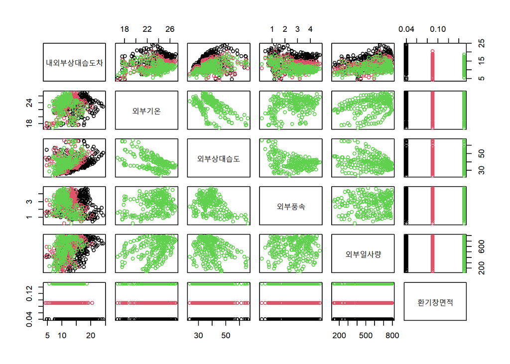

```r
pairs(ex1,col=factor(ex1$환기창면적))
```

- 환기창면적과 다른 주효과들간의 뚜렷한 교호작용이 관측되지는 않는다.
- 산점도를 통해 알 수 있는 사실은 외부기온과 외부일사량이 증가할수록 내외부상대습도차도 증가한다는 점이다. 외부풍속은 약하지만 내부상대습도차와 음의 상관을 보이는 것으로 생각된다.

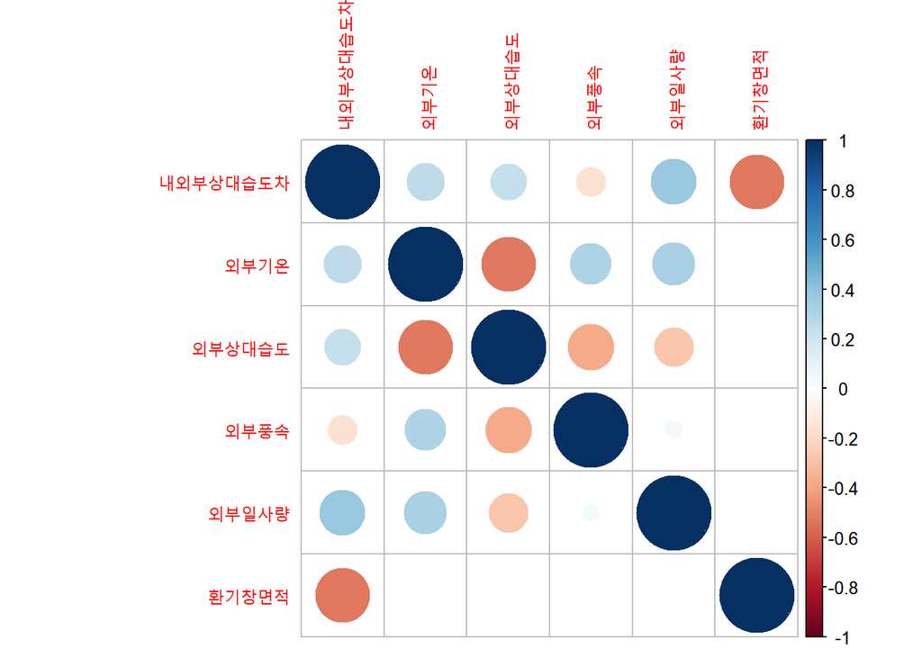

```r
library(corrplot)
corrplot(cor(ex1)) # 상관계수행렬을 그림으로 표현해주는 함수
```

- 그리고 각 변수에 대한 기초통계량은 다음과 같이 계산된다.

```r
library(psych)
describe(ex1) # 각 변수에 대한 기초통계량을 계산해주는 함수
```

```
##                  vars   n   mean     sd median trimmed    mad    min    max
## 내외부상대습도차    1 735  13.13   3.49  12.90   13.02   3.71   4.30  24.30
## 외부기온            2 735  23.39   2.30  24.00   23.66   1.93  16.80  27.00
## 외부상대습도        3 735  39.39   7.86  38.70   38.68   6.08  23.60  65.90
## 외부풍속            4 735   2.71   1.08   2.87    2.73   1.29   0.21   4.74
## 외부일사량          5 735 568.60 171.31 601.10  584.32 191.40 143.00 795.20
## 환기창면적          6 735   0.09   0.04   0.09    0.09   0.07   0.04   0.15
##                   range  skew kurtosis   se
## 내외부상대습도차  20.00  0.32    -0.23 0.13
## 외부기온          10.20 -0.98     0.30 0.08
## 외부상대습도      42.30  1.00     1.43 0.29
## 외부풍속           4.54 -0.26    -0.99 0.04
## 외부일사량       652.20 -0.63    -0.61 6.32
## 환기창면적         0.11  0.11    -1.50 0.00
```

- 내외부상대습도차를 반응변수로 하여 각 변수의 주효과와 모든 가능한 교호작용을 고려한 다중선형회귀모형을 적합하면 다음과 같다.
- 사전분석 결과 환기창면적과 다른 변수들과의 교호작용 뿐 아니라 다른 효과들도 비교적 유의미하게 관측되었기 때문이다.

```r
m_no <- lm(내외부상대습도차~(외부기온+외부상대습도+외부풍속+외부일사량+환기창면적)^2,data=plantno) # 다중회귀모형 구축 함수
summary(m_no)
```

```
##
## Call:
## lm(formula = 내외부상대습도차 ~ (외부기온 + 외부상대습도 + 외부풍속 +
##     외부일사량 + 환기창면적)^2, data = plantno)
##
## Residuals:
##     Min      1Q  Median      3Q     Max
## -7.7770 -0.7891  0.1060  0.8476  7.5192
##
## Coefficients:
##                           Estimate Std. Error t value Pr(>|t|)
## (Intercept)             -3.436e+01  8.867e+00  -3.874 0.000117 ***
## 외부기온                 1.134e+00  3.940e-01   2.879 0.004108 **
## 외부상대습도             1.877e-01  1.351e-01   1.390 0.165090
## 외부풍속                 4.398e+00  1.367e+00   3.218 0.001350 **
## 외부일사량               2.422e-02  8.449e-03   2.866 0.004277 **
## 환기창면적               1.258e+02  2.281e+01   5.513 4.91e-08 ***
## 외부기온:외부상대습도    4.973e-03  6.865e-03   0.724 0.469040
## 외부기온:외부풍속        2.250e-02  4.621e-02   0.487 0.626485
## 외부기온:외부일사량     -5.217e-04  2.858e-04  -1.826 0.068340 .
## 외부기온:환기창면적     -4.633e+00  7.457e-01  -6.213 8.81e-10 ***
## 외부상대습도:외부풍속   -6.057e-02  1.257e-02  -4.818 1.77e-06 ***
## 외부상대습도:외부일사량  2.207e-04  8.415e-05   2.623 0.008902 **
## 외부상대습도:환기창면적 -4.759e-01  2.204e-01  -2.159 0.031152 *
## 외부풍속:외부일사량     -3.796e-03  4.476e-04  -8.482  < 2e-16 ***
## 외부풍속:환기창면적     -7.836e+00  1.427e+00  -5.490 5.59e-08 ***
## 외부일사량:환기창면적   -3.191e-02  8.783e-03  -3.633 0.000300 ***
## ---
## Signif. codes:  0 '***' 0.001 '**' 0.01 '*' 0.05 '.' 0.1 ' ' 1
##
## Residual standard error: 1.708 on 719 degrees of freedom
## Multiple R-squared:  0.7653, Adjusted R-squared:  0.7604
## F-statistic: 156.3 on 15 and 719 DF,  p-value: < 2.2e-16
```

- 모형적합 결과 외부기온과 외부상대습도, 외부기온과 외부풍속, 그리고 외부기온과 외부일사량 사이의 교호작용이 유의수준 0.05에서 유의미하지 않다.
- 그리고 교호작용들 중 외부풍속과 외부일사량, 그리고 외부기온과 환기창면적 사이의 교호작용에 대한 t 통계량의 절대값이 각각 첫번째와 두번째로 가장 크므로 이를 가장 중요한 2가지의 교호작용으로 결정한다.
- 조정된 결정계수의 값이 $R^2_{adj}=0.7604$이다.

#### Best subset selection

- 여러 측도들을 이용하여 모형에 포함될 변수를 적절히 선택해 보도록 하겠다.

```r
library(leaps)
# 다양한 측도에 따라 모형에 포함될 변수의 개수를 결정해주는 함수
ms0 <- regsubsets(내외부상대습도차~(외부기온+외부상대습도+외부풍속+외부일사량+환기창면적)^2,data=plantno,nvmax=15)
ms0.summary <- summary(ms0)
ms0.summary
```

```
## Subset selection object
## Call: regsubsets.formula(내외부상대습도차 ~ (외부기온 + 외부상대습도 +
##     외부풍속 + 외부일사량 + 환기창면적)^2, data = plantno, nvmax = 15)
## 15 Variables  (and intercept)
##                         Forced in Forced out
## 외부기온                    FALSE      FALSE
## 외부상대습도                FALSE      FALSE
## 외부풍속                    FALSE      FALSE
## 외부일사량                  FALSE      FALSE
## 환기창면적                  FALSE      FALSE
## 외부기온:외부상대습도       FALSE      FALSE
## 외부기온:외부풍속           FALSE      FALSE
## 외부기온:외부일사량         FALSE      FALSE
## 외부기온:환기창면적         FALSE      FALSE
## 외부상대습도:외부풍속       FALSE      FALSE
```

[output cut: 87 more lines]

```r
par(mfrow=c(2,2))
# RSS=SSE
plot(ms0.summary$rss,xlab="Number of Variables",ylab="RSS",type="l")
# Adj R^2
plot(ms0.summary$adjr2,xlab="Number of Variables",ylab="Adjusted RSq",type="l")
which.max(ms0.summary$adjr2)
```

```
## [1] 13
```

```r
points(which.max(ms0.summary$adjr2)
,ms0.summary$adjr2[which.max(ms0.summary$adjr2)
], col="red",cex=2,pch=20)
# Cp
plot(ms0.summary$cp,xlab="Number of Variables",ylab="Cp",type='l')
which.min(ms0.summary$cp)
```

```
## [1] 13
```

```r
points(which.min(ms0.summary$cp)
,ms0.summary$cp[which.min(ms0.summary$cp)
],col="red",cex=2,pch=20)
# BIC
plot(ms0.summary$bic,xlab="Number of Variables",ylab="BIC",type='l')
which.min(ms0.summary$bic)
```

```
## [1] 11
```

```r
points(which.min(ms0.summary$bic)
,ms0.summary$bic[which.min(ms0.summary$bic)
],col="red",cex=2,pch=20)
```

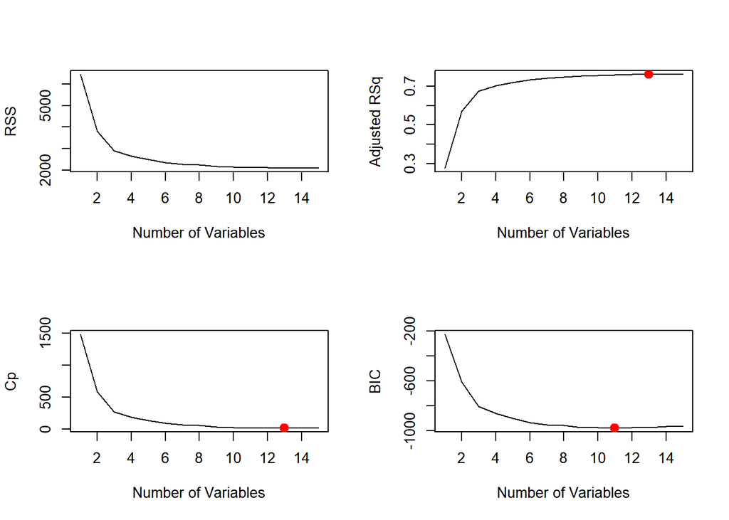

```r
par(mfrow=c(1,1))
```

- 전체적으로 변수가 11~13개 정도면 안정화되는 경향이 보인다.

#### 교차타당검증에 의한 모형 비교

- 지금부터는 train:test=7:3 으로 데이터를 나누어서 몇 개의 후보 모형들의 test RMSE를 계산하여 보겠다. 이 값이 작을수록 예측력이 우수한 모형이라고 볼 수 있다.
- 먼저 데이터를 임의로 train:test=7:3 의 비율로 나눈다. train data는 모형구축 시, test data는 구축된 모형을 평가 시 사용한다.
- 모형에 대한 성능은 test RMSE와 SSE/SST를 바탕으로 실시하며, 두가지 기준 모두 그 값이 작을수록 모형의 예측력이 우수하다고 판단하면 된다.
- $RMSE=\sqrt{{\frac {1}{n} \sum_{i=1}^{n} (y_{i}-\hat{y_{i}})^{2}}}$
- $SSE/SST=\frac {\sum_{i=1}^{n} (y_{i}-\hat{y_{i}})^{2}} {\sum_{i=1}^{n} (y_{i}-\bar{y})^{2}}$

```r
set.seed(5790)
train.index <- sample(1:nrow(plantno), round(nrow(plantno)*7/10), replace=F)
ex1_train <- plantno[train.index,]
ex1_test <- plantno[-train.index,]
```

```r
# model1 : 모든 주효과 및 교호작용을 포함한 모형
m0 <- lm(내외부상대습도차~(외부기온+외부상대습도+외부풍속+외부일사량+환기창면적)^2,data=ex1_train)
y_hat0 <- predict(m0,ex1_test)
RMSE0 <- sqrt(mean((ex1_test$내외부상대습도차-y_hat0)^2))
SSE0 <- sum((ex1_test$내외부상대습도차-y_hat0)^2)
SST0 <- sum((ex1_test$내외부상대습도차-mean(ex1_test$내외부상대습도차))^2)
result0 <- data.frame(ex1_test$내외부상대습도차, y_hat0, ex1_test$내외부상대습도차-y_hat0)
colnames(result0) <- c('y','yhat','y-yhat')
RMSE0 # test RMSE
```

```
## [1] 1.642016
```

```r
SSE0/SST0 # SSE/SST
```

```
## [1] 0.206264
```

```r
head(result0,12)
```

```
##       y      yhat       y-yhat
## 3   9.7  9.093142  0.606858330
## 5   8.4  9.273947 -0.873947246
## 7  10.5  9.908544  0.591455573
## 10 13.5 10.951174  2.548826070
## 12 12.8 12.357378  0.442622417
## 17 15.0 13.515209  1.484791372
## 20 14.3 13.816085  0.483914953
## 24 15.0 14.998148  0.001852409
## 33 13.5 14.753621 -1.253620872
## 51  9.6 12.323260 -2.723260199
## 60 19.7 16.412074  3.287926064
## 62 20.1 16.678396  3.421604230
```

```r
# model2 : Adj R^2, Cp, BIC 기준에 의하여 선택된 모형
m0 <- lm(내외부상대습도차~외부기온+외부풍속+외부일사량+환기창면적+외부기온*외부상대습도+외부기온*환기창면적+외부상대습도*외부풍속+외부상대습도*외부일사량+외부풍속*외부일사량+외부풍속*환기창면적+외부일사량*환기창면적,data=ex1_train)
y_hat0 <- predict(m0,ex1_test)
RMSE1 <- sqrt(mean((ex1_test$내외부상대습도차-y_hat0)^2))
SSE1 <- sum((ex1_test$내외부상대습도차-y_hat0)^2)
SST1 <- sum((ex1_test$내외부상대습도차-mean(ex1_test$내외부상대습도차))^2)
result1 <- data.frame(ex1_test$내외부상대습도차, y_hat0, ex1_test$내외부상대습도차-y_hat0)
colnames(result1) <- c('y','yhat','y-yhat')
RMSE1 # test RMSE
```

```
## [1] 1.651247
```

```r
SSE1/SST1 # SSE/SST
```

```
## [1] 0.2085897
```

```r
head(result1,12)
```

```
##       y      yhat       y-yhat
## 3   9.7  9.255386  0.444613765
## 5   8.4  9.531322 -1.131321949
## 7  10.5 10.088638  0.411361876
## 10 13.5 10.921477  2.578522920
## 12 12.8 12.227196  0.572803828
## 17 15.0 13.378349  1.621651448
## 20 14.3 13.739209  0.560790860
## 24 15.0 14.991940  0.008059546
## 33 13.5 14.851624 -1.351623958
## 51  9.6 12.275547 -2.675547116
## 60 19.7 16.261774  3.438225837
## 62 20.1 16.542099  3.557900873
```

```r
# model3 : 모든 주효과, 그리고 중요한 2개의 교호작용을 포함한 모형
m0 <- lm(내외부상대습도차~외부기온+외부상대습도+외부풍속+외부일사량+환기창면적+외부풍속*외부일사량+외부기온*환기창면적,data=ex1_train)
y_hat0 <- predict(m0,ex1_test)
RMSE2 <- sqrt(mean((ex1_test$내외부상대습도차-y_hat0)^2))
SSE2 <- sum((ex1_test$내외부상대습도차-y_hat0)^2)
SST2 <- sum((ex1_test$내외부상대습도차-mean(ex1_test$내외부상대습도차))^2)
result2 <- data.frame(ex1_test$내외부상대습도차, y_hat0, ex1_test$내외부상대습도차-y_hat0)
colnames(result2) <- c('y','yhat','y-yhat')
RMSE2 # test RMSE
```

```
## [1] 1.698344
```

```r
SSE2/SST2 # SSE/SST
```

```
## [1] 0.2206582
```

```r
head(result2,12)
```

```
##       y      yhat     y-yhat
## 3   9.7  9.822171 -0.1221710
## 5   8.4  9.356787 -0.9567873
## 7  10.5  9.404767  1.0952329
## 10 13.5  9.965850  3.5341501
## 12 12.8 11.528962  1.2710378
## 17 15.0 12.350307  2.6496934
## 20 14.3 12.672470  1.6275305
## 24 15.0 14.391593  0.6084067
## 33 13.5 13.748739 -0.2487391
## 51  9.6 12.537721 -2.9377212
## 60 19.7 16.382681  3.3173190
## 62 20.1 16.704355  3.3956449
```

```r
# model4 : 모든 주효과, 그리고 외부풍속과 외부일사량과의 교호작용 1개만을 포함한 모형
m0 <- lm(내외부상대습도차~외부기온+외부상대습도+외부풍속+외부일사량+환기창면적+외부풍속*외부일사량,data=ex1_train)
y_hat0 <- predict(m0,ex1_test)
RMSE3 <- sqrt(mean((ex1_test$내외부상대습도차-y_hat0)^2))
SSE3 <- sum((ex1_test$내외부상대습도차-y_hat0)^2)
SST3 <- sum((ex1_test$내외부상대습도차-mean(ex1_test$내외부상대습도차))^2)
result3 <- data.frame(ex1_test$내외부상대습도차, y_hat0, ex1_test$내외부상대습도차-y_hat0)
colnames(result3) <- c('y','yhat','y-yhat')
RMSE3 # test RMSE
```

```
## [1] 1.752224
```

```r
SSE3/SST3 # SSE/SST
```

```
## [1] 0.234881
```

```r
head(result3,12)
```

```
##       y     yhat      y-yhat
## 3   9.7 11.70312 -2.00312328
## 5   8.4 11.15504 -2.75503749
## 7  10.5 11.17857 -0.67857395
## 10 13.5 11.64680  1.85319892
## 12 12.8 12.74242  0.05758126
## 17 15.0 13.10164  1.89835791
## 20 14.3 13.12372  1.17628125
## 24 15.0 14.40630  0.59370278
## 33 13.5 13.55810 -0.05809566
## 51  9.6 14.21037 -4.61036573
## 60 19.7 17.04332  2.65668280
## 62 20.1 17.20407  2.89592546
```

```r
# model5 : 모든 주효과, 그리고 외부기온과 환기창면적과의 교호작용 1개만을 포함한 모형
m0 <- lm(내외부상대습도차~외부기온+외부상대습도+외부풍속+외부일사량+환기창면적+외부기온*환기창면적,data=ex1_train)
y_hat0 <- predict(m0,ex1_test)
RMSE4 <- sqrt(mean((ex1_test$내외부상대습도차-y_hat0)^2))
SSE4 <- sum((ex1_test$내외부상대습도차-y_hat0)^2)
SST4 <- sum((ex1_test$내외부상대습도차-mean(ex1_test$내외부상대습도차))^2)
result4 <- data.frame(ex1_test$내외부상대습도차, y_hat0, ex1_test$내외부상대습도차-y_hat0)
colnames(result4) <- c('y','yhat','y-yhat')
RMSE4 # test RMSE
```

```
## [1] 1.764174
```

```r
SSE4/SST4 # SSE/SST
```

```
## [1] 0.2380959
```

```r
head(result4,12)
```

```
##       y      yhat     y-yhat
## 3   9.7  9.828266 -0.1282661
## 5   8.4  8.872308 -0.4723080
## 7  10.5  8.894460  1.6055398
## 10 13.5  9.690852  3.8091479
## 12 12.8 11.384649  1.4153506
## 17 15.0 12.847866  2.1521336
## 20 14.3 13.337867  0.9621327
## 24 15.0 14.837614  0.1623864
## 33 13.5 14.119661 -0.6196614
## 51  9.6 12.924188 -3.3241882
## 60 19.7 15.573335  4.1266649
## 62 20.1 15.836565  4.2634347
```

### 2.2 작물이 있을 때

#### Multiple Linear Regression Model

- 먼저 변수들 간의 상관관계를 파악하기 위해 상관분석을 실시한다.

```r
ex1 <- plantyes[,c(6,1,4,10,11,13)]
head(ex1)
```

```
##   내외부상대습도차 외부기온 외부상대습도 외부풍속 외부일사량 환기창면적
## 1             23.7     22.9         78.7    1.398      372.7       0.15
## 2             18.4     22.8         77.1    1.326      309.9       0.15
## 3             17.1     23.3         75.5    0.835      291.9       0.15
## 4             15.1     23.6         72.9    0.943      297.5       0.15
## 5             14.8     24.0         71.2    1.481      335.4       0.15
## 6             17.0     25.1         66.6    1.132      549.7       0.15
```

```r
cor(ex1)
```

```
##                  내외부상대습도차    외부기온 외부상대습도    외부풍속
## 내외부상대습도차       1.00000000  0.02106138   0.01525967 -0.20440308
## 외부기온               0.02106138  1.00000000  -0.75407969  0.12445561
## 외부상대습도           0.01525967 -0.75407969   1.00000000 -0.05691617
## 외부풍속              -0.20440308  0.12445561  -0.05691617  1.00000000
## 외부일사량             0.57456886  0.47323743  -0.57992727  0.01247939
## 환기창면적            -0.26190157 -0.08617862   0.09732684  0.10718424
##                   외부일사량  환기창면적
## 내외부상대습도차  0.57456886 -0.26190157
## 외부기온          0.47323743 -0.08617862
## 외부상대습도     -0.57992727  0.09732684
## 외부풍속          0.01247939  0.10718424
## 외부일사량        1.00000000 -0.01979362
## 환기창면적       -0.01979362  1.00000000
```

- 산점도행렬과 상관계수그림을 그리면 다음과 같다.

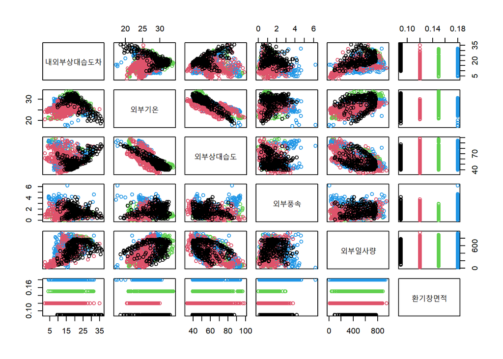

```r
pairs(ex1,col=factor(ex1$환기창면적))
```

- 환기창면적과 다른 주효과들간의 뚜렷한 교호작용이 관측되지는 않는다.
- 독립변수들과 내부상대습도와의 연관성의 방향은 작물이 없을 때와 유사해 보인다.

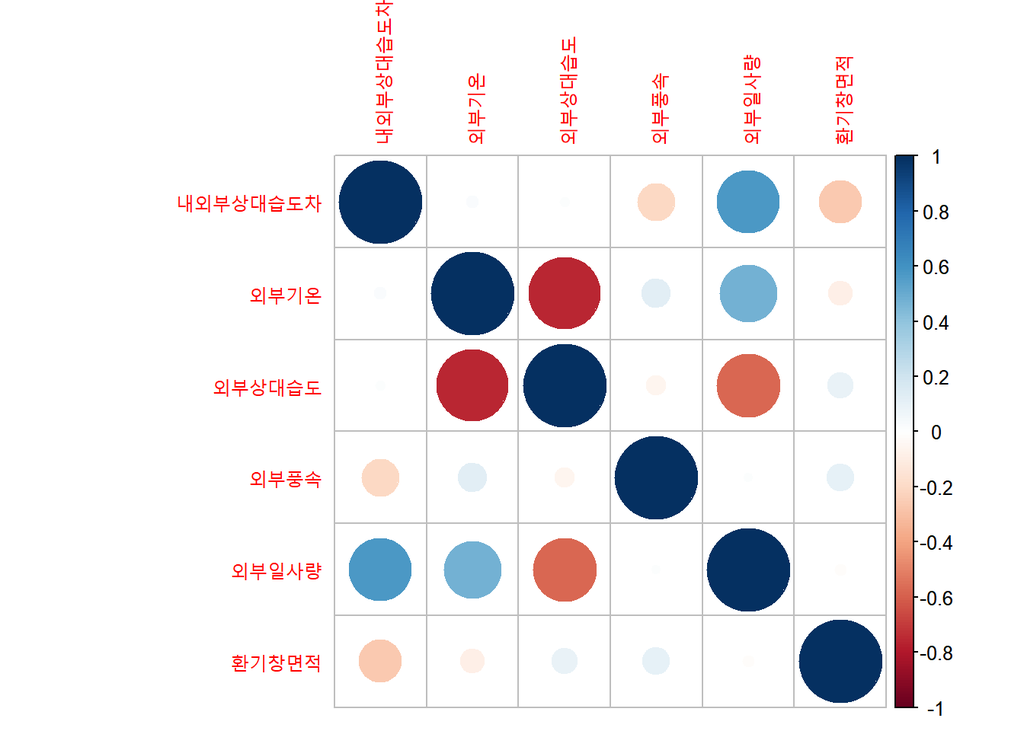

```r
library(corrplot)
corrplot(cor(ex1))
```

- 그리고 각 변수에 대한 기초통계량은 다음과 같이 계산된다.

```r
library(psych)
describe(ex1)
```

```
##                  vars    n   mean     sd median trimmed    mad   min    max
## 내외부상대습도차    1 1055  16.54   6.20  16.10   16.24   5.93  2.00  36.40
## 외부기온            2 1055  26.91   2.99  26.90   26.94   3.26 17.30  33.90
## 외부상대습도        3 1055  59.45  13.87  57.20   58.35  13.94 33.30  98.80
## 외부풍속            4 1055   1.50   0.92   1.30    1.41   0.83  0.00   6.22
## 외부일사량          5 1055 459.27 225.19 459.20  460.76 275.02 10.04 950.00
## 환기창면적          6 1055   0.13   0.03   0.12    0.13   0.04  0.09   0.18
##                   range  skew kurtosis   se
## 내외부상대습도차  34.40  0.43     0.10 0.19
## 외부기온          16.60 -0.12    -0.42 0.09
## 외부상대습도      65.50  0.63    -0.26 0.43
## 외부풍속           6.21  0.97     0.80 0.03
## 외부일사량       939.96 -0.02    -1.02 6.93
## 환기창면적         0.09  0.12    -1.38 0.00
```

- 내외부상대습도차를 반응변수로 하여 각 변수의 주효과와 모든 가능한 교호작용을 고려한 다중선형회귀모형을 적합하면 다음과 같다.
- 모든 교호작용을 함께 고려한 것은, 사전분석 결과 환기창면적과 다른 변수들과의 교호작용 뿐 아니라 다른 효과들도 비교적 유의미하게 관측되었기 때문이다.

```r
m_yes <- lm(내외부상대습도차~(외부기온+외부상대습도+외부풍속+외부일사량+환기창면적)^2,data=plantyes)
summary(m_yes)
```

```
##
## Call:
## lm(formula = 내외부상대습도차 ~ (외부기온 + 외부상대습도 + 외부풍속 +
##     외부일사량 + 환기창면적)^2, data = plantyes)
##
## Residuals:
##      Min       1Q   Median       3Q      Max
## -10.1057  -1.5820  -0.1209   1.4222  11.1897
##
## Coefficients:
##                           Estimate Std. Error t value Pr(>|t|)
## (Intercept)             -8.009e+01  9.240e+00  -8.667  < 2e-16 ***
## 외부기온                 3.110e+00  2.653e-01  11.722  < 2e-16 ***
## 외부상대습도             7.573e-01  7.762e-02   9.756  < 2e-16 ***
## 외부풍속                 1.458e+01  1.753e+00   8.320 2.75e-16 ***
## 외부일사량               3.445e-02  7.423e-03   4.641 3.92e-06 ***
## 환기창면적               7.120e+00  5.891e+01   0.121 0.903829
## 외부기온:외부상대습도   -2.686e-02  2.594e-03 -10.353  < 2e-16 ***
## 외부기온:외부풍속       -3.322e-01  4.263e-02  -7.793 1.58e-14 ***
## 외부기온:외부일사량     -1.700e-03  2.054e-04  -8.277 3.86e-16 ***
## 외부기온:환기창면적     -6.245e-01  1.464e+00  -0.427 0.669765
## 외부상대습도:외부풍속   -5.983e-02  1.045e-02  -5.728 1.33e-08 ***
## 외부상대습도:외부일사량  8.166e-04  3.983e-05  20.501  < 2e-16 ***
## 외부상대습도:환기창면적  1.087e-01  3.523e-01   0.309 0.757747
## 외부풍속:외부일사량     -2.733e-03  4.994e-04  -5.473 5.54e-08 ***
## 외부풍속:환기창면적     -9.936e+00  2.703e+00  -3.676 0.000249 ***
## 외부일사량:환기창면적   -6.053e-02  1.353e-02  -4.473 8.56e-06 ***
## ---
## Signif. codes:  0 '***' 0.001 '**' 0.01 '*' 0.05 '.' 0.1 ' ' 1
##
## Residual standard error: 2.534 on 1039 degrees of freedom
## Multiple R-squared:  0.8356, Adjusted R-squared:  0.8332
## F-statistic: 352.1 on 15 and 1039 DF,  p-value: < 2.2e-16
```

- 모형적합 결과 환기창면적, 외부기온과 환기창면적 사이의 교호작용, 그리고 외부상대습도와 환기창면적 사이의 교호작용이 유의수준 0.05에서 유의미하지 않았다. 하지만 환기창면적의 경우는 다른 변수들과의 교호작용이 유의미한 경우가 존재하기 때문에 제외할 필요는 없다고 판단된다. 그리고 조정된 결정계수의 값은 $R^2_{adj}=0.8332$이다.
- 그리고 여러 교호작용들 중 t 통계량의 절대값이 가장 큰 외부상대습도와 외부일사량 사이의 교호작용을 1차적으로 고려해 볼 수 있다. 외부기온과 외부일사량 사이의 교호작용, 외부기온과 외부상대습도와의 교호작용 또한 유의미해 보인다.
- 전체적으로 환기창면적과의 교호작용 뿐 아니라 다양한 교호작용들이 유의미하게 나타난다. 추가로 환기창면적의 경우는 외부일사량과의 교호작용이 다른것들과 비교했을 때 가장 유의미하다.

#### Best subset selection

- 여러 측도들을 이용하여 모형에 포함될 변수를 적절히 선택해 보도록 하겠다.

```r
library(leaps)
ms0 <- regsubsets(내외부상대습도차~(외부기온+외부상대습도+외부풍속+외부일사량+환기창면적)^2,data=plantyes,nvmax=15)
ms0.summary <- summary(ms0)
ms0.summary
```

```
## Subset selection object
## Call: regsubsets.formula(내외부상대습도차 ~ (외부기온 + 외부상대습도 +
##     외부풍속 + 외부일사량 + 환기창면적)^2, data = plantyes, nvmax = 15)
## 15 Variables  (and intercept)
##                         Forced in Forced out
## 외부기온                    FALSE      FALSE
## 외부상대습도                FALSE      FALSE
## 외부풍속                    FALSE      FALSE
## 외부일사량                  FALSE      FALSE
## 환기창면적                  FALSE      FALSE
## 외부기온:외부상대습도       FALSE      FALSE
## 외부기온:외부풍속           FALSE      FALSE
## 외부기온:외부일사량         FALSE      FALSE
## 외부기온:환기창면적         FALSE      FALSE
## 외부상대습도:외부풍속       FALSE      FALSE
```

[output cut: 87 more lines]

```r
par(mfrow=c(2,2))
# RSS=SSE
plot(ms0.summary$rss,xlab="Number of Variables",ylab="RSS",type="l")
# Adj R^2
plot(ms0.summary$adjr2,xlab="Number of Variables",ylab="Adjusted RSq",type="l")
which.max(ms0.summary$adjr2)
```

```
## [1] 12
```

```r
points(which.max(ms0.summary$adjr2)
,ms0.summary$adjr2[which.max(ms0.summary$adjr2)
], col="red",cex=2,pch=20)
# Cp
plot(ms0.summary$cp,xlab="Number of Variables",ylab="Cp",type='l')
which.min(ms0.summary$cp)
```

```
## [1] 12
```

```r
points(which.min(ms0.summary$cp)
,ms0.summary$cp[which.min(ms0.summary$cp)
],col="red",cex=2,pch=20)
# BIC
plot(ms0.summary$bic,xlab="Number of Variables",ylab="BIC",type='l')
which.min(ms0.summary$bic)
```

```
## [1] 12
```

```r
points(which.min(ms0.summary$bic)
,ms0.summary$bic[which.min(ms0.summary$bic)
],col="red",cex=2,pch=20)
```

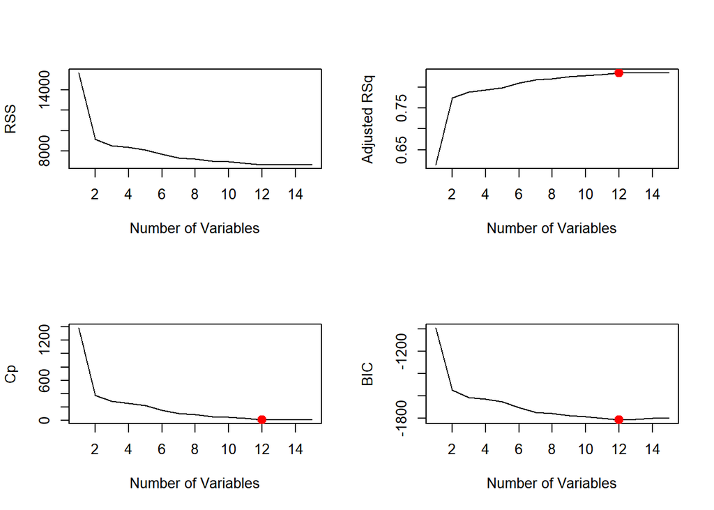

```r
par(mfrow=c(1,1))
```

- 전체적으로 변수의 개수가 11~13일 때 안정화되는 경향이 있다.
- 분석결과 $R_{adj}^2$, $Cp$, 그리고 $BIC$ 모두 변수의 개수 12인 모형을 최적으로 판단하고 있다.

#### 교차타당검증에 의한 모형 비교

- 지금부터는 train:test=7:3 으로 데이터를 나누어서 몇 개의 후보 모형들의 test RMSE를 계산하여 보겠다. 이 값이 작을수록 예측력이 우수한 모형이라고 볼 수 있다.
- 먼저 데이터를 임의로 train:test=7:3 의 비율로 나눈다. train data는 모형구축 시, test data는 구축된 모형을 평가 시 사용한다.
- 모형에 대한 성능은 test RMSE와 SSE/SST를 바탕으로 실시하며, 두가지 기준 모두 그 값이 작을수록 모형의 예측력이 우수하다고 판단하면 된다.
- $RMSE=\sqrt{{\frac {1}{n} \sum_{i=1}^{n} (y_{i}-\hat{y_{i}})^{2}}}$
- $SSE/SST=\frac {\sum_{i=1}^{n} (y_{i}-\hat{y_{i}})^{2}} {\sum_{i=1}^{n} (y_{i}-\bar{y})^{2}}$

```r
set.seed(5790)
train.index <- sample(1:nrow(plantyes), round(nrow(plantyes)*7/10), replace=F)
ex1_train <- plantyes[train.index,]
ex1_test <- plantyes[-train.index,]
```

```r
# model1 : 모든 주효과 및 교호작용을 포함한 모형
m0 <- lm(내외부상대습도차~(외부기온+외부상대습도+외부풍속+외부일사량+환기창면적)^2,data=ex1_train)
y_hat0 <- predict(m0,ex1_test)
RMSE0 <- sqrt(mean((ex1_test$내외부상대습도차-y_hat0)^2))
SSE0 <- sum((ex1_test$내외부상대습도차-y_hat0)^2)
SST0 <- sum((ex1_test$내외부상대습도차-mean(ex1_test$내외부상대습도차))^2)
result0 <- data.frame(ex1_test$내외부상대습도차, y_hat0, ex1_test$내외부상대습도차-y_hat0)
colnames(result0) <- c('y','yhat','y-yhat')
RMSE0 # test RMSE
```

```
## [1] 2.563821
```

```r
SSE0/SST0 # SSE/SST
```

```
## [1] 0.1509973
```

```r
head(result0,12)
```

```
##       y      yhat     y-yhat
## 3  17.1 16.228104  0.8718958
## 5  14.8 16.810690 -2.0106904
## 10 17.7 21.925136 -4.2251356
## 12 20.6 22.217841 -1.6178413
## 17 16.6 17.766243 -1.1662431
## 20 17.9 18.395856 -0.4958557
## 23 12.7 15.661479 -2.9614793
## 24 15.3 16.479091 -1.1790915
## 33 16.1 14.906892  1.1931077
## 39 12.9 14.200438 -1.3004378
## 45 14.5 12.714157  1.7858425
## 54  6.9  7.968793 -1.0687930
```

```r
# model2 : Adj R^2, Cp, BIC 기준에 의하여 선택된 모형
m0 <- lm(내외부상대습도차~외부기온+외부상대습도+외부풍속+외부일사량+외부기온*외부상대습도+외부기온*외부일사량+외부상대습도*외부풍속+외부상대습도*외부일사량+외부기온*외부풍속+외부풍속*외부일사량+외부풍속*환기창면적+외부일사량*환기창면적,data=ex1_train)
y_hat0 <- predict(m0,ex1_test)
RMSE1 <- sqrt(mean((ex1_test$내외부상대습도차-y_hat0)^2))
SSE1 <- sum((ex1_test$내외부상대습도차-y_hat0)^2)
SST1 <- sum((ex1_test$내외부상대습도차-mean(ex1_test$내외부상대습도차))^2)
result1 <- data.frame(ex1_test$내외부상대습도차, y_hat0, ex1_test$내외부상대습도차-y_hat0)
colnames(result1) <- c('y','yhat','y-yhat')
RMSE1 # test RMSE
```

```
## [1] 2.552447
```

```r
SSE1/SST1 # SSE/SST
```

```
## [1] 0.1496605
```

```r
head(result1,12)
```

```
##       y      yhat     y-yhat
## 3  17.1 16.109415  0.9905852
## 5  14.8 16.734182 -1.9341819
## 10 17.7 21.878552 -4.1785517
## 12 20.6 22.161257 -1.5612568
## 17 16.6 17.802644 -1.2026436
## 20 17.9 18.452034 -0.5520337
## 23 12.7 15.793502 -3.0935022
## 24 15.3 16.574913 -1.2749133
## 33 16.1 15.154448  0.9455517
## 39 12.9 14.452000 -1.5520001
## 45 14.5 12.867439  1.6325614
## 54  6.9  7.956208 -1.0562075
```

```r
# model3 : 모든 주효과, 그리고 중요한 3개의 교호작용을 포함한 모형
m0 <- lm(내외부상대습도차~외부기온+외부상대습도+외부풍속+외부일사량+환기창면적+외부상대습도*외부일사량+외부기온*외부상대습도+외부기온*외부일사량,data=ex1_train)
y_hat0 <- predict(m0,ex1_test)
RMSE2 <- sqrt(mean((ex1_test$내외부상대습도차-y_hat0)^2))
SSE2 <- sum((ex1_test$내외부상대습도차-y_hat0)^2)
SST2 <- sum((ex1_test$내외부상대습도차-mean(ex1_test$내외부상대습도차))^2)
result2 <- data.frame(ex1_test$내외부상대습도차, y_hat0, ex1_test$내외부상대습도차-y_hat0)
colnames(result2) <- c('y','yhat','y-yhat')
RMSE2 # test RMSE
```

```
## [1] 2.785837
```

```r
SSE2/SST2 # SSE/SST
```

```
## [1] 0.178281
```

```r
head(result2,12)
```

```
##       y      yhat     y-yhat
## 3  17.1 16.069803  1.0301971
## 5  14.8 16.353117 -1.5531167
## 10 17.7 21.507670 -3.8076696
## 12 20.6 21.587424 -0.9874236
## 17 16.6 17.418394 -0.8183939
## 20 17.9 17.719615  0.1803854
## 23 12.7 15.197526 -2.4975262
## 24 15.3 16.453619 -1.1536185
## 33 16.1 15.024531  1.0754686
## 39 12.9 14.617547 -1.7175466
## 45 14.5 12.745069  1.7549313
## 54  6.9  7.240863 -0.3408634
```

```r
# model4 : 모든 주효과, 그리고 외부상대습도와 외부일사량과의 교호작용 1개만을 포함한 모형
m0 <- lm(내외부상대습도차~외부기온+외부상대습도+외부풍속+외부일사량+환기창면적+외부상대습도*외부일사량,data=ex1_train)
y_hat0 <- predict(m0,ex1_test)
RMSE3 <- sqrt(mean((ex1_test$내외부상대습도차-y_hat0)^2))
SSE3 <- sum((ex1_test$내외부상대습도차-y_hat0)^2)
SST3 <- sum((ex1_test$내외부상대습도차-mean(ex1_test$내외부상대습도차))^2)
result3 <- data.frame(ex1_test$내외부상대습도차, y_hat0, ex1_test$내외부상대습도차-y_hat0)
colnames(result3) <- c('y','yhat','y-yhat')
RMSE3 # test RMSE
```

```
## [1] 2.843424
```

```r
SSE3/SST3 # SSE/SST
```

```
## [1] 0.1857278
```

```r
head(result3,12)
```

```
##       y      yhat      y-yhat
## 3  17.1 15.972348  1.12765236
## 5  14.8 16.553665 -1.75366476
## 10 17.7 21.963491 -4.26349074
## 12 20.6 22.034733 -1.43473315
## 17 16.6 17.703123 -1.10312270
## 20 17.9 17.872148  0.02785202
## 23 12.7 14.570784 -1.87078436
## 24 15.3 16.340827 -1.04082735
## 33 16.1 15.800707  0.29929310
## 39 12.9 13.084157 -0.18415685
## 45 14.5 11.697525  2.80247451
## 54  6.9  5.603496  1.29650391
```

```r
# model5 : 모든 주효과, 그리고 외부일사량과 환기창면적과의 교호작용 1개만을 포함한 모형
m0 <- lm(내외부상대습도차~외부기온+외부상대습도+외부풍속+외부일사량+환기창면적+환기창면적*외부일사량,data=ex1_train)
y_hat0 <- predict(m0,ex1_test)
RMSE4 <- sqrt(mean((ex1_test$내외부상대습도차-y_hat0)^2))
SSE4 <- sum((ex1_test$내외부상대습도차-y_hat0)^2)
SST4 <- sum((ex1_test$내외부상대습도차-mean(ex1_test$내외부상대습도차))^2)
result4 <- data.frame(ex1_test$내외부상대습도차, y_hat0, ex1_test$내외부상대습도차-y_hat0)
colnames(result4) <- c('y','yhat','y-yhat')
RMSE4 # test RMSE
```

```
## [1] 3.725771
```

```r
SSE4/SST4 # SSE/SST
```

```
## [1] 0.3188791
```

```r
head(result4,12)
```

```
##       y      yhat     y-yhat
## 3  17.1 16.305226  0.7947743
## 5  14.8 15.566199 -0.7661989
## 10 17.7 20.094440 -2.3944403
## 12 20.6 21.049169 -0.4491691
## 17 16.6 16.808719 -0.2087189
## 20 17.9 18.048727 -0.1487272
## 23 12.7 14.501947 -1.8019468
## 24 15.3 16.241456 -0.9414564
## 33 16.1 21.738441 -5.6384409
## 39 12.9 16.388383 -3.4883826
## 45 14.5  9.560847  4.9391533
## 54  6.9 14.458294 -7.5582940
```

- 결과적으로 Adj R^2, Cp, BIC 기준에 의하여 선택된 모형이 가장 우수하였다.
- `:`표시는 교호작용을 의미함.
- model1 : 모든 주효과 및 교호작용을 포함한 모형
  - 반응변수 : 내외부상대습도차
  - 설명변수 : 외부기온, 외부상대습도, 외부풍속, 외부일사량, 환기창면적, 외부기온:외부상대습도, 외부기온:외부풍속, 외부기온:외부일사량, 외부기온:환기창면적, 외부상대습도:외부풍속, 외부상대습도:외부일사량, 외부상대습도:환기창면적, 외부풍속:외부일사량, 외부풍속:환기창면적, 외부일사량:환기창면적
  - RMSE=2.5638, SSE/SST=0.1510
- model2 : Adj R^2, Cp, BIC 기준에 의하여 선택된 모형
  - 반응변수 : 내외부상대습도차
  - 설명변수 : 외부기온, 외부상대습도, 외부풍속, 외부일사량, 외부기온:외부상대습도, 외부기온:외부일사량, 외부상대습도:외부풍속, 외부상대습도:외부일사량, 외부기온:외부풍속, 외부풍속:외부일사량, 외부풍속:환기창면적, 외부일사량:환기창면적
  - RMSE=2.5524, SSE/SST=0.1497
- model3 : 모든 주효과, 그리고 중요한 3개의 교호작용을 포함한 모형
  - 반응변수 : 내외부상대습도차
  - 설명변수 : 외부기온, 외부상대습도, 외부풍속, 외부일사량, 환기창면적, 외부상대습도:외부일사량, 외부기온:외부상대습도, 외부기온:외부일사량
  - RMSE=2.7858, SSE/SST=0.1783
- model4 : 모든 주효과, 그리고 외부상대습도와 외부일사량과의 교호작용 1개만을 포함한 모형
  - 반응변수 : 내외부상대습도차
  - 설명변수 : 외부기온, 외부상대습도, 외부풍속, 외부일사량, 환기창면적, 외부상대습도:외부일사량
  - RMSE=2.8434, SSE/SST=0.1857
- model5 : 모든 주효과, 그리고 외부일사량과 환기창면적과의 교호작용 1개만을 포함한 모형
  - 반응변수 : 내외부상대습도차
  - 설명변수 : 외부기온, 외부상대습도, 외부풍속, 외부일사량, 환기창면적, 환기창면적:외부일사량
  - RMSE=3.7258, SSE/SST=0.3189

### 2.3 작물유무 데이터를 합친 경우

#### Multiple Linear Regression Model

- 상관관계에 대한 분석은 작물유무에 따라 데이터를 나누어 분석하는 과정에서 모두 다루었기 때문에 생략하도록 한다.
- 2.1절과 2.2절의 결과를 통해 외부풍속과 외부일사량, 그리고 외부상대습도와 외부일사량 사이의 교호작용이 유의미하다는 사실을 파악할 수 있다.
- 여기에서는 작물유무에 대한 변수가 추가로 들어가고 이에 따라 작물유무에 대한 교호작용을 포함해서 다양한 교호작용 변수를 고려할 수 있지만 모형이 너무 복잡해지므로 바람직하지 않다. 오히려 중요한 교호작용만을 포함한 모형도 충분한 설명력을 가지기 때문이다.
- 따라서 내외부상대습도차를 반응변수로 하여 각 변수의 주효과와 외부풍속과 외부일사량, 그리고 외부상대습도와 외부일사량 사이의 교호작용을 포함한 모형을 시작점으로 하여 분석을 진행하도록 한다. 여기에 주효과와 작물유무 사이의 교호작용도 우선 포함한다.

```r
m_total <- lm(내외부상대습도차~외부기온+외부상대습도+외부풍속+외부일사량+환기창면적+작물유무+외부풍속*외부일사량+외부상대습도*외부일사량+작물유무*외부기온+작물유무*외부상대습도+작물유무*외부풍속+작물유무*외부일사량+작물유무*환기창면적,data=plant)
summary(m_total)
```

```
##
## Call:
## lm(formula = 내외부상대습도차 ~ 외부기온 + 외부상대습도 + 외부풍속 +
##     외부일사량 + 환기창면적 + 작물유무 + 외부풍속 * 외부일사량 +
##     외부상대습도 * 외부일사량 + 작물유무 * 외부기온 + 작물유무 *
##     외부상대습도 + 작물유무 * 외부풍속 + 작물유무 * 외부일사량 +
##     작물유무 * 환기창면적, data = plant)
##
## Residuals:
##     Min      1Q  Median      3Q     Max
## -9.8532 -1.3018  0.0437  1.3177 11.6445
##
## Coefficients:
##                            Estimate Std. Error t value Pr(>|t|)
## (Intercept)               1.865e+00  1.651e+00   1.129 0.258866
## 외부기온                  5.426e-01  4.995e-02  10.863  < 2e-16 ***
## 외부상대습도             -1.399e-01  1.909e-02  -7.328 3.53e-13 ***
## 외부풍속                  1.203e+00  1.966e-01   6.119 1.16e-09 ***
## 외부일사량               -1.557e-02  1.460e-03 -10.668  < 2e-16 ***
## 환기창면적               -4.070e+01  2.063e+00 -19.727  < 2e-16 ***
## 작물유무yes               7.244e+00  2.223e+00   3.259 0.001141 **
## 외부풍속:외부일사량      -2.506e-03  2.972e-04  -8.434  < 2e-16 ***
## 외부상대습도:외부일사량   7.885e-04  2.546e-05  30.964  < 2e-16 ***
## 외부기온:작물유무yes     -3.727e-01  6.401e-02  -5.822 6.89e-09 ***
## 외부상대습도:작물유무yes  1.177e-01  1.784e-02   6.599 5.44e-11 ***
## 외부풍속:작물유무yes     -5.572e-01  1.375e-01  -4.053 5.28e-05 ***
## 외부일사량:작물유무yes   -2.076e-03  9.377e-04  -2.214 0.026978 *
## 환기창면적:작물유무yes   -1.172e+01  3.117e+00  -3.760 0.000175 ***
## ---
## Signif. codes:  0 '***' 0.001 '**' 0.01 '*' 0.05 '.' 0.1 ' ' 1
##
## Residual standard error: 2.515 on 1776 degrees of freedom
## Multiple R-squared:  0.794,  Adjusted R-squared:  0.7925
## F-statistic: 526.6 on 13 and 1776 DF,  p-value: < 2.2e-16
```

- 모형적합 결과 모든 주효과와 교호작용이 유의수준 0.05에서 유의미하다.
- 그리고 가장 중요한 교호작용은 세가지를 선택할 수 있는데 외부상대습도와 외부일사량, 외부풍속과 외부일사량, 그리고 외부상대습도와 작물유무 사이의 교호작용이라고 판단된다.
- 조정된 결정계수의 값이 $R^2_{adj}=0.7925$이다.

#### Best subset selection

- 여러 측도들을 이용하여 모형에 포함될 변수를 적절히 선택해 보도록 하겠다.

```r
library(leaps)
ms0 <- regsubsets(내외부상대습도차~외부기온+외부상대습도+외부풍속+외부일사량+환기창면적+작물유무+외부풍속*외부일사량+외부상대습도*외부일사량+작물유무*외부기온+작물유무*외부상대습도+작물유무*외부풍속+작물유무*외부일사량+작물유무*환기창면적,data=plant,nvmax=13)
ms0.summary <- summary(ms0)
ms0.summary
```

```
## Subset selection object
## Call: regsubsets.formula(내외부상대습도차 ~ 외부기온 + 외부상대습도 +
##     외부풍속 + 외부일사량 + 환기창면적 + 작물유무 + 외부풍속 *
##     외부일사량 + 외부상대습도 * 외부일사량 + 작물유무 * 외부기온 +
##     작물유무 * 외부상대습도 + 작물유무 * 외부풍속 + 작물유무 *
##     외부일사량 + 작물유무 * 환기창면적, data = plant, nvmax = 13)
## 13 Variables  (and intercept)
##                          Forced in Forced out
## 외부기온                     FALSE      FALSE
## 외부상대습도                 FALSE      FALSE
## 외부풍속                     FALSE      FALSE
## 외부일사량                   FALSE      FALSE
## 환기창면적                   FALSE      FALSE
## 작물유무yes                  FALSE      FALSE
## 외부풍속:외부일사량          FALSE      FALSE
## 외부상대습도:외부일사량      FALSE      FALSE
## 외부기온:작물유무yes         FALSE      FALSE
## 외부상대습도:작물유무yes     FALSE      FALSE
## 외부풍속:작물유무yes         FALSE      FALSE
## 외부일사량:작물유무yes       FALSE      FALSE
## 환기창면적:작물유무yes       FALSE      FALSE
## 1 subsets of each size up to 13
## Selection Algorithm: exhaustive
##           외부기온 외부상대습도 외부풍속 외부일사량 환기창면적 작물유무yes
## 1  ( 1 )  " "      " "          " "      " "        " "        " "
## 2  ( 1 )  " "      " "          " "      "*"        " "        " "
## 3  ( 1 )  " "      " "          " "      "*"        "*"        " "
## 4  ( 1 )  "*"      " "          " "      "*"        "*"        " "
## 5  ( 1 )  "*"      " "          " "      "*"        "*"        " "
## 6  ( 1 )  "*"      " "          " "      "*"        "*"        "*"
## 7  ( 1 )  "*"      "*"          " "      "*"        "*"        " "
## 8  ( 1 )  "*"      "*"          " "      "*"        "*"        " "
## 9  ( 1 )  "*"      "*"          "*"      "*"        "*"        " "
## 10  ( 1 ) "*"      "*"          "*"      "*"        "*"        " "
## 11  ( 1 ) "*"      "*"          "*"      "*"        "*"        " "
## 12  ( 1 ) "*"      "*"          "*"      "*"        "*"        "*"
## 13  ( 1 ) "*"      "*"          "*"      "*"        "*"        "*"
##           외부풍속:외부일사량 외부상대습도:외부일사량 외부기온:작물유무yes
## 1  ( 1 )  " "                 "*"                     " "
## 2  ( 1 )  " "                 "*"                     " "
```

[output cut: 24 more lines]

```
## 13  ( 1 ) "*"                      "*"                  "*"
##           환기창면적:작물유무yes
## 1  ( 1 )  " "
## 2  ( 1 )  " "
## 3  ( 1 )  " "
## 4  ( 1 )  " "
## 5  ( 1 )  " "
## 6  ( 1 )  " "
## 7  ( 1 )  " "
## 8  ( 1 )  " "
## 9  ( 1 )  " "
## 10  ( 1 ) " "
## 11  ( 1 ) "*"
## 12  ( 1 ) "*"
## 13  ( 1 ) "*"
```

```r
par(mfrow=c(2,2))
# RSS=SSE
plot(ms0.summary$rss,xlab="Number of Variables",ylab="RSS",type="l")
# Adj R^2
plot(ms0.summary$adjr2,xlab="Number of Variables",ylab="Adjusted RSq",type="l")
which.max(ms0.summary$adjr2)
```

```
## [1] 13
```

```r
points(which.max(ms0.summary$adjr2)
,ms0.summary$adjr2[which.max(ms0.summary$adjr2)
], col="red",cex=2,pch=20)
# Cp
plot(ms0.summary$cp,xlab="Number of Variables",ylab="Cp",type='l')
which.min(ms0.summary$cp)
```

```
## [1] 13
```

```r
points(which.min(ms0.summary$cp)
,ms0.summary$cp[which.min(ms0.summary$cp)
],col="red",cex=2,pch=20)
# BIC
plot(ms0.summary$bic,xlab="Number of Variables",ylab="BIC",type='l')
which.min(ms0.summary$bic)
```

```
## [1] 12
```

```r
points(which.min(ms0.summary$bic)
,ms0.summary$bic[which.min(ms0.summary$bic)
],col="red",cex=2,pch=20)
```

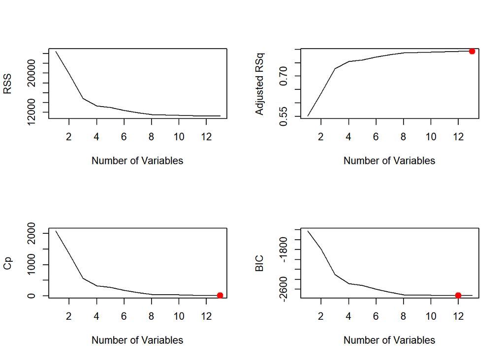

```r
par(mfrow=c(1,1))
```

- 분석결과 $R_{adj}^2$와 $Cp$는 변수의 개수 13인 모형, 그리고 $BIC$는 변수의 개수 12인 모형을 최적으로 판단하고 있다.

#### 교차타당검증에 의한 모형 비교

- 지금부터는 train:test=7:3 으로 데이터를 나누어서 몇 개의 후보 모형들의 test RMSE를 계산하여 보겠다. 이 값이 작을수록 예측력이 우수한 모형이라고 볼 수 있다.
- 먼저 데이터를 임의로 train:test=7:3 의 비율로 나눈다. train data는 모형구축 시, test data는 구축된 모형을 평가 시 사용한다.
- 모형에 대한 성능은 test RMSE와 SSE/SST를 바탕으로 실시하며, 두가지 기준 모두 그 값이 작을수록 모형의 예측력이 우수하다고 판단하면 된다.
- $RMSE=\sqrt{{\frac {1}{n} \sum_{i=1}^{n} (y_{i}-\hat{y_{i}})^{2}}}$
- $SSE/SST=\frac {\sum_{i=1}^{n} (y_{i}-\hat{y_{i}})^{2}} {\sum_{i=1}^{n} (y_{i}-\bar{y})^{2}}$

```r
set.seed(5790)
train.index <- sample(1:nrow(plant), round(nrow(plant)*7/10), replace=F)
ex1_train <- plant[train.index,]
ex1_test <- plant[-train.index,]
```

```r
# model1 : 최초로 고려한 모형
m0 <- lm(내외부상대습도차~외부기온+외부상대습도+외부풍속+외부일사량+환기창면적+작물유무+외부풍속*외부일사량+외부상대습도*외부일사량+작물유무*외부기온+작물유무*외부상대습도+작물유무*외부풍속+작물유무*외부일사량+작물유무*환기창면적,data=ex1_train)
y_hat0 <- predict(m0,ex1_test)
RMSE0 <- sqrt(mean((ex1_test$내외부상대습도차-y_hat0)^2))
SSE0 <- sum((ex1_test$내외부상대습도차-y_hat0)^2)
SST0 <- sum((ex1_test$내외부상대습도차-mean(ex1_test$내외부상대습도차))^2)
result0 <- data.frame(ex1_test$내외부상대습도차, y_hat0, ex1_test$내외부상대습도차-y_hat0)
colnames(result0) <- c('y','yhat','y-yhat')
RMSE0 # test RMSE
```

```
## [1] 2.566846
```

```r
SSE0/SST0 # SSE/SST
```

```
## [1] 0.2175177
```

```r
head(result0,12)
```

```
##       y     yhat      y-yhat
## 3   9.7 12.40111 -2.70111457
## 12 12.8 12.58563  0.21437350
## 15 13.8 11.66927  2.13073347
## 17 15.0 12.57653  2.42346763
## 23 14.3 13.08296  1.21704135
## 24 15.0 13.07386  1.92613643
## 37 13.6 13.15519  0.44481001
## 39 12.9 12.95520 -0.05519749
## 43 13.2 12.53964  0.66036324
## 48 10.0 11.63734 -1.63734060
## 51  9.6 14.58033 -4.98033083
## 57 16.6 16.61464 -0.01464369
```

```r
# model2 : Adj R^2, Cp, BIC 등의 기준을 바탕으로 선택된 모형 (외부일사량과 작물유무 사이의 교호작용 제외)
m0 <- lm(내외부상대습도차~외부기온+외부상대습도+외부풍속+외부일사량+환기창면적+작물유무+외부풍속*외부일사량+외부상대습도*외부일사량+작물유무*외부기온+작물유무*외부상대습도+작물유무*외부풍속+작물유무*환기창면적,data=ex1_train)
y_hat0 <- predict(m0,ex1_test)
RMSE1 <- sqrt(mean((ex1_test$내외부상대습도차-y_hat0)^2))
SSE1 <- sum((ex1_test$내외부상대습도차-y_hat0)^2)
SST1 <- sum((ex1_test$내외부상대습도차-mean(ex1_test$내외부상대습도차))^2)
result1 <- data.frame(ex1_test$내외부상대습도차, y_hat0, ex1_test$내외부상대습도차-y_hat0)
colnames(result1) <- c('y','yhat','y-yhat')
RMSE1 # test RMSE
```

```
## [1] 2.570193
```

```r
SSE1/SST1 # SSE/SST
```

```
## [1] 0.2180853
```

```r
head(result1,12)
```

```
##       y     yhat     y-yhat
## 3   9.7 12.37564 -2.6756407
## 12 12.8 12.41885  0.3811486
## 15 13.8 11.53969  2.2603065
## 17 15.0 12.43020  2.5698018
## 23 14.3 12.98031  1.3196933
## 24 15.0 12.98680  2.0132048
## 37 13.6 13.19784  0.4021615
## 39 12.9 13.01281 -0.1128118
## 43 13.2 12.63765  0.5623465
## 48 10.0 11.86151 -1.8615057
## 51  9.6 14.59788 -4.9978827
## 57 16.6 16.46228  0.1377232
```

```r
# model3 : 모든 주효과와 가장 중요한 교호작용 1가지(외부상대습도과 외부일사량)를 포함한 모형
m0 <- lm(내외부상대습도차~외부기온+외부상대습도+외부풍속+외부일사량+환기창면적+작물유무+외부상대습도*외부일사량,data=ex1_train)
y_hat0 <- predict(m0,ex1_test)
RMSE2 <- sqrt(mean((ex1_test$내외부상대습도차-y_hat0)^2))
SSE2 <- sum((ex1_test$내외부상대습도차-y_hat0)^2)
SST2 <- sum((ex1_test$내외부상대습도차-mean(ex1_test$내외부상대습도차))^2)
result2 <- data.frame(ex1_test$내외부상대습도차, y_hat0, ex1_test$내외부상대습도차-y_hat0)
colnames(result2) <- c('y','yhat','y-yhat')
RMSE2 # test RMSE
```

```
## [1] 2.774776
```

```r
SSE2/SST2 # SSE/SST
```

```
## [1] 0.2541855
```

```r
head(result2,12)
```

```
##       y     yhat     y-yhat
## 3   9.7 14.15020 -4.4502046
## 12 12.8 13.59677 -0.7967704
## 15 13.8 12.97953  0.8204662
## 17 15.0 13.72066  1.2793381
## 23 14.3 12.91908  1.3809190
## 24 15.0 13.28854  1.7114636
## 37 13.6 12.37622  1.2237761
## 39 12.9 12.23853  0.6614651
## 43 13.2 12.01397  1.1860331
## 48 10.0 11.20299 -1.2029938
## 51  9.6 17.48297 -7.8829748
## 57 16.6 17.80772 -1.2077219
```

```r
# model4 : 모든 주효과와 가장 중요한 교호작용 2가지(외부상대습도과 외부일사량, 외부풍속과 외부일사량)를 포함한 모형
m0 <- lm(내외부상대습도차~외부기온+외부상대습도+외부풍속+외부일사량+환기창면적+작물유무+외부상대습도*외부일사량+외부풍속*외부일사량,data=ex1_train)
y_hat0 <- predict(m0,ex1_test)
RMSE3 <- sqrt(mean((ex1_test$내외부상대습도차-y_hat0)^2))
SSE3 <- sum((ex1_test$내외부상대습도차-y_hat0)^2)
SST3 <- sum((ex1_test$내외부상대습도차-mean(ex1_test$내외부상대습도차))^2)
result3 <- data.frame(ex1_test$내외부상대습도차, y_hat0, ex1_test$내외부상대습도차-y_hat0)
colnames(result3) <- c('y','yhat','y-yhat')
RMSE3 # test RMSE
```

```
## [1] 2.766766
```

```r
SSE3/SST3 # SSE/SST
```

```
## [1] 0.25272
```

```r
head(result3,12)
```

```
##       y     yhat     y-yhat
## 3   9.7 14.44304 -4.7430354
## 12 12.8 13.48765 -0.6876484
## 15 13.8 12.35985  1.4401511
## 17 15.0 13.19809  1.8019089
## 23 14.3 12.89956  1.4004368
## 24 15.0 12.94510  2.0548961
## 37 13.6 12.54408  1.0559218
## 39 12.9 12.39676  0.5032384
## 43 13.2 12.30466  0.8953357
## 48 10.0 11.55622 -1.5562162
## 51  9.6 17.58158 -7.9815751
## 57 16.6 18.16841 -1.5684066
```

```r
# model5 : 모든 주효과, 그리고 외부상대습도와 작물유무 사이의 교호작용을 포함한 모형
m0 <- lm(내외부상대습도차~외부기온+외부상대습도+외부풍속+외부일사량+환기창면적+작물유무+외부상대습도*작물유무,data=ex1_train)
y_hat0 <- predict(m0,ex1_test)
RMSE4 <- sqrt(mean((ex1_test$내외부상대습도차-y_hat0)^2))
SSE4 <- sum((ex1_test$내외부상대습도차-y_hat0)^2)
SST4 <- sum((ex1_test$내외부상대습도차-mean(ex1_test$내외부상대습도차))^2)
result4 <- data.frame(ex1_test$내외부상대습도차, y_hat0, ex1_test$내외부상대습도차-y_hat0)
colnames(result4) <- c('y','yhat','y-yhat')
RMSE4 # test RMSE
```

```
## [1] 3.419131
```

```r
SSE4/SST4 # SSE/SST
```

```
## [1] 0.3859458
```

```r
head(result4,12)
```

```
##       y      yhat      y-yhat
## 3   9.7 14.001103 -4.30110258
## 12 12.8 15.839125 -3.03912529
## 15 13.8 15.790016 -1.99001642
## 17 15.0 16.738447 -1.73844702
## 23 14.3 17.597862 -3.29786221
## 24 15.0 17.374725 -2.37472525
## 37 13.6 14.074050 -0.47404969
## 39 12.9 12.922261 -0.02226051
## 43 13.2 10.661274  2.53872614
## 48 10.0  7.721405  2.27859540
## 51  9.6 16.084540 -6.48454029
## 57 16.6 17.642783 -1.04278267
```

```r
# model6 : 모든 주효과, 그리고 환기창면적과 작물유무 사이의 교호작용을 포함한 모형
m0 <- lm(내외부상대습도차~외부기온+외부상대습도+외부풍속+외부일사량+환기창면적+작물유무+환기창면적*작물유무,data=ex1_train)
y_hat0 <- predict(m0,ex1_test)
RMSE5 <- sqrt(mean((ex1_test$내외부상대습도차-y_hat0)^2))
SSE5 <- sum((ex1_test$내외부상대습도차-y_hat0)^2)
SST5 <- sum((ex1_test$내외부상대습도차-mean(ex1_test$내외부상대습도차))^2)
result5 <- data.frame(ex1_test$내외부상대습도차, y_hat0, ex1_test$내외부상대습도차-y_hat0)
colnames(result5) <- c('y','yhat','y-yhat')
RMSE5 # test RMSE
```

```
## [1] 3.411434
```

```r
SSE5/SST5 # SSE/SST
```

```
## [1] 0.3842102
```

```r
head(result5,12)
```

```
##       y      yhat     y-yhat
## 3   9.7 13.786192 -4.0861921
## 12 12.8 15.622917 -2.8229172
## 15 13.8 15.581761 -1.7817614
## 17 15.0 16.526411 -1.5264110
## 23 14.3 17.332698 -3.0326978
## 24 15.0 17.128001 -2.1280013
## 37 13.6 13.786876 -0.1868762
## 39 12.9 12.643896  0.2561039
## 43 13.2 10.396596  2.8034042
## 48 10.0  7.446965  2.5530350
## 51  9.6 15.946959 -6.3469586
## 57 16.6 17.450554 -0.8505537
```